# Hankowsky_HW10

2022-11-10

Hankowsky Homework Solutions

# Basic Problems

## 20.16

```r
#read in the data
sparrows <- Sleuth3::ex2016

#take a look at the dataset
head(sparrows)
```

```
##     Status AG  TL  AE   WT   BH   HL   FL   TT   SK   KL
## 1 Survived  1 154 241 24.5 31.2 0.69 0.67 1.02 0.59 0.83
## 2 Survived  1 160 252 26.9 30.8 0.74 0.71 1.18 0.60 0.84
## 3 Survived  1 155 243 26.9 30.6 0.73 0.70 1.15 0.60 0.85
## 4 Survived  1 154 245 24.3 31.7 0.74 0.69 1.15 0.58 0.84
## 5 Survived  1 156 247 24.1 31.5 0.71 0.71 1.13 0.57 0.82
## 6 Survived  1 161 253 26.5 31.8 0.78 0.74 1.14 0.61 0.89
```

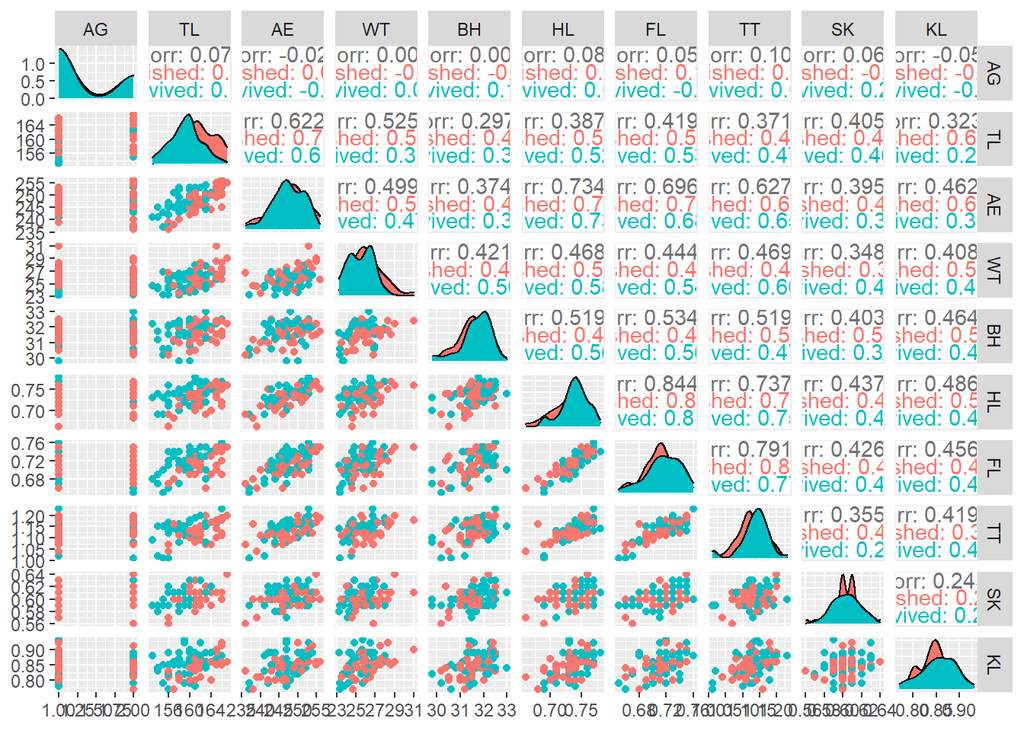

```r
#scatterplot matrix
ggpairs(sparrows, columns = 2:11, ggplot2::aes(color = Status))
```

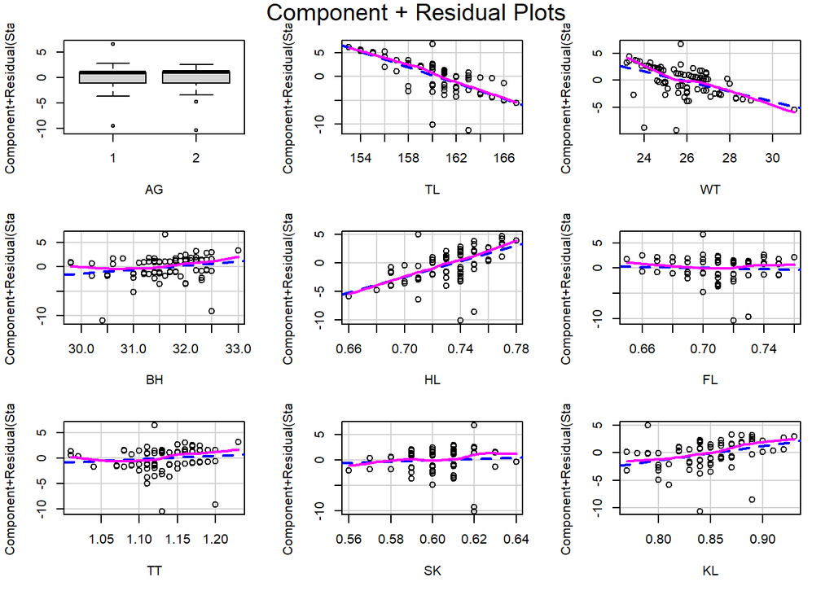

```r
#run the model
#change to factor
sparrows <- sparrows %>%
  mutate(AG = as.factor(AG))

sparrow_glm <- glm(Status ~ AG + TL + WT + BH + HL + FL + TT + SK + KL, family = binomial, data = sparrows)

crPlots(sparrow_glm)
```

```r
#looks like there an effect of TL, WT, HL, and maybe a slight KL
#after accounting for other variables

# REGRESSION ANALYSIS USING BACKWARD ELIMINATION
sparrow_glm1 <- glm(Status ~ AG + TL + WT + BH + HL + FL + TT + SK + KL, family = binomial, data = sparrows)
summary(sparrow_glm1)
```

```
##
## Call:
## glm(formula = Status ~ AG + TL + WT + BH + HL + FL + TT + SK +
##     KL, family = binomial, data = sparrows)
##
## Deviance Residuals:
##     Min       1Q   Median       3Q      Max
## -2.1641  -0.5065   0.1541   0.5295   1.9411
##
## Coefficients:
##             Estimate Std. Error z value Pr(>|z|)
## (Intercept) 36.57091   22.41446   1.632  0.10277
## AG2          0.02806    0.67050   0.042  0.96662
## TL          -0.69894    0.17908  -3.903  9.5e-05 ***
## WT          -0.86760    0.33605  -2.582  0.00983 **
## BH           0.51044    0.57815   0.883  0.37730
## HL          63.48659   28.85043   2.201  0.02777 *
## FL          -6.98431   31.44673  -0.222  0.82424
## TT           6.46812   13.70413   0.472  0.63694
## SK          20.47026   26.64990   0.768  0.44242
## KL          24.79175   11.90003   2.083  0.03722 *
## ---
## Signif. codes:  0 '***' 0.001 '**' 0.01 '*' 0.05 '.' 0.1 ' ' 1
##
## (Dispersion parameter for binomial family taken to be 1)
##
##     Null deviance: 118.008  on 86  degrees of freedom
## Residual deviance:  66.358  on 77  degrees of freedom
## AIC: 86.358
##
## Number of Fisher Scoring iterations: 6
```

```r
sparrow_glm2 <- update(sparrow_glm1, ~ . - AG)
summary(sparrow_glm2)
```

```
##
## Call:
## glm(formula = Status ~ TL + WT + BH + HL + FL + TT + SK + KL,
##     family = binomial, data = sparrows)
##
## Deviance Residuals:
##     Min       1Q   Median       3Q      Max
## -2.1570  -0.5084   0.1537   0.5351   1.9364
##
## Coefficients:
##             Estimate Std. Error z value Pr(>|z|)
## (Intercept)  36.5034    22.3772   1.631  0.10283
## TL           -0.6982     0.1781  -3.921 8.83e-05 ***
## WT           -0.8689     0.3349  -2.594  0.00948 **
## BH            0.5104     0.5784   0.883  0.37750
## HL           63.4777    28.8494   2.200  0.02778 *
## FL           -7.0523    31.4020  -0.225  0.82231
## TT            6.4712    13.7177   0.472  0.63711
## SK           20.5387    26.6117   0.772  0.44024
## KL           24.7870    11.9085   2.081  0.03739 *
## ---
## Signif. codes:  0 '***' 0.001 '**' 0.01 '*' 0.05 '.' 0.1 ' ' 1
##
## (Dispersion parameter for binomial family taken to be 1)
##
##     Null deviance: 118.01  on 86  degrees of freedom
## Residual deviance:  66.36  on 78  degrees of freedom
## AIC: 84.36
##
## Number of Fisher Scoring iterations: 6
```

```r
sparrow_glm3 <- update(sparrow_glm2, ~ . - FL)
summary(sparrow_glm3)
```

```
##
## Call:
## glm(formula = Status ~ TL + WT + BH + HL + TT + SK + KL, family = binomial,
##     data = sparrows)
##
## Deviance Residuals:
##     Min       1Q   Median       3Q      Max
## -2.1807  -0.5193   0.1424   0.5218   1.9225
##
## Coefficients:
##             Estimate Std. Error z value Pr(>|z|)
## (Intercept)  36.8847    22.2968   1.654  0.09807 .
## TL           -0.7007     0.1777  -3.944 8.02e-05 ***
## WT           -0.8624     0.3324  -2.595  0.00947 **
## BH            0.4891     0.5710   0.857  0.39166
## HL           59.9455    24.0918   2.488  0.01284 *
## TT            4.7479    11.3699   0.418  0.67625
## SK           20.8324    26.5330   0.785  0.43237
## KL           24.6350    11.8894   2.072  0.03826 *
## ---
## Signif. codes:  0 '***' 0.001 '**' 0.01 '*' 0.05 '.' 0.1 ' ' 1
##
## (Dispersion parameter for binomial family taken to be 1)
##
##     Null deviance: 118.01  on 86  degrees of freedom
## Residual deviance:  66.41  on 79  degrees of freedom
## AIC: 82.41
##
## Number of Fisher Scoring iterations: 6
```

```r
sparrow_glm4 <- update(sparrow_glm3, ~ . - TT)
summary(sparrow_glm4)
```

```
##
## Call:
## glm(formula = Status ~ TL + WT + BH + HL + SK + KL, family = binomial,
##     data = sparrows)
##
## Deviance Residuals:
##     Min       1Q   Median       3Q      Max
## -2.1559  -0.5221   0.1523   0.5308   1.9600
##
## Coefficients:
##             Estimate Std. Error z value Pr(>|z|)
## (Intercept)  35.1445    21.8668   1.607  0.10801
## TL           -0.6916     0.1744  -3.966 7.31e-05 ***
## WT           -0.8473     0.3283  -2.581  0.00985 **
## BH            0.5345     0.5576   0.959  0.33780
## HL           65.1081    21.3385   3.051  0.00228 **
## SK           20.9032    26.4328   0.791  0.42906
## KL           24.6188    11.8527   2.077  0.03780 *
## ---
## Signif. codes:  0 '***' 0.001 '**' 0.01 '*' 0.05 '.' 0.1 ' ' 1
##
## (Dispersion parameter for binomial family taken to be 1)
##
##     Null deviance: 118.008  on 86  degrees of freedom
## Residual deviance:  66.581  on 80  degrees of freedom
## AIC: 80.581
##
## Number of Fisher Scoring iterations: 6
```

```r
sparrow_glm5 <- update(sparrow_glm4, ~ . - SK)
summary(sparrow_glm5)
```

```
##
## Call:
## glm(formula = Status ~ TL + WT + BH + HL + KL, family = binomial,
##     data = sparrows)
##
## Deviance Residuals:
##     Min       1Q   Median       3Q      Max
## -1.9635  -0.5645   0.1492   0.6004   2.1646
##
## Coefficients:
##             Estimate Std. Error z value Pr(>|z|)
## (Intercept)  41.5162    20.1743   2.058  0.03960 *
## TL           -0.6888     0.1758  -3.919 8.91e-05 ***
## WT           -0.8604     0.3240  -2.655  0.00792 **
## BH            0.6371     0.5390   1.182  0.23716
## HL           68.0605    20.9756   3.245  0.00118 **
## KL           25.4462    11.9957   2.121  0.03390 *
## ---
## Signif. codes:  0 '***' 0.001 '**' 0.01 '*' 0.05 '.' 0.1 ' ' 1
##
## (Dispersion parameter for binomial family taken to be 1)
##
##     Null deviance: 118.008  on 86  degrees of freedom
## Residual deviance:  67.214  on 81  degrees of freedom
## AIC: 79.214
##
## Number of Fisher Scoring iterations: 6
```

```r
sparrow_glm6 <- update(sparrow_glm5, ~ . - BH)
summary(sparrow_glm6)
```

```
##
## Call:
## glm(formula = Status ~ TL + WT + HL + KL, family = binomial,
##     data = sparrows)
##
## Deviance Residuals:
##     Min       1Q   Median       3Q      Max
## -2.2234  -0.5648   0.1540   0.6094   2.2701
##
## Coefficients:
##             Estimate Std. Error z value Pr(>|z|)
## (Intercept)  49.9861    18.4879   2.704 0.006857 **
## TL           -0.6573     0.1683  -3.907 9.35e-05 ***
## WT           -0.7896     0.3097  -2.549 0.010800 *
## HL           72.3327    20.7640   3.484 0.000495 ***
## KL           27.3775    11.7780   2.324 0.020101 *
## ---
## Signif. codes:  0 '***' 0.001 '**' 0.01 '*' 0.05 '.' 0.1 ' ' 1
##
## (Dispersion parameter for binomial family taken to be 1)
##
##     Null deviance: 118.008  on 86  degrees of freedom
## Residual deviance:  68.612  on 82  degrees of freedom
## AIC: 78.612
##
## Number of Fisher Scoring iterations: 6
```

```r
#run the optimal model
sparrow_glm_optimal <- glm(Status ~ TL + WT + HL + KL, family = binomial, data = sparrows)
summary(sparrow_glm_optimal)
```

```
##
## Call:
## glm(formula = Status ~ TL + WT + HL + KL, family = binomial,
##     data = sparrows)
##
## Deviance Residuals:
##     Min       1Q   Median       3Q      Max
## -2.2234  -0.5648   0.1540   0.6094   2.2701
##
## Coefficients:
##             Estimate Std. Error z value Pr(>|z|)
## (Intercept)  49.9861    18.4879   2.704 0.006857 **
## TL           -0.6573     0.1683  -3.907 9.35e-05 ***
## WT           -0.7896     0.3097  -2.549 0.010800 *
## HL           72.3327    20.7640   3.484 0.000495 ***
## KL           27.3775    11.7780   2.324 0.020101 *
## ---
## Signif. codes:  0 '***' 0.001 '**' 0.01 '*' 0.05 '.' 0.1 ' ' 1
##
## (Dispersion parameter for binomial family taken to be 1)
##
##     Null deviance: 118.008  on 86  degrees of freedom
## Residual deviance:  68.612  on 82  degrees of freedom
## AIC: 78.612
##
## Number of Fisher Scoring iterations: 6
```

```r
#run the null model
sparrow_glm_null <- glm(Status ~ 1, family = binomial, data = sparrows)
summary(sparrow_glm_null)
```

```
##
## Call:
## glm(formula = Status ~ 1, family = binomial, data = sparrows)
##
## Deviance Residuals:
##    Min      1Q  Median      3Q     Max
## -1.328  -1.328   1.034   1.034   1.034
##
## Coefficients:
##             Estimate Std. Error z value Pr(>|z|)
## (Intercept)   0.3483     0.2177     1.6     0.11
##
## (Dispersion parameter for binomial family taken to be 1)
##
##     Null deviance: 118.01  on 86  degrees of freedom
## Residual deviance: 118.01  on 86  degrees of freedom
## AIC: 120.01
##
## Number of Fisher Scoring iterations: 4
```

```r
#drop in deviance
anova(sparrow_glm_optimal, sparrow_glm_null, test = "Chisq")
```

```
## Analysis of Deviance Table
##
## Model 1: Status ~ TL + WT + HL + KL
## Model 2: Status ~ 1
##   Resid. Df Resid. Dev Df Deviance  Pr(>Chi)
## 1        82     68.612
## 2        86    118.008 -4  -49.396 4.826e-10 ***
## ---
## Signif. codes:  0 '***' 0.001 '**' 0.01 '*' 0.05 '.' 0.1 ' ' 1
```

**Basic 20.16_3rd** Excellent work. You used a backward selection procedure to arrive at 4 key variables. If you check the VIFs, you’ll find that with the full set of variables, many of the variables had VIFs greater than 4 indicating problems with multicollinearity. There are a variety of solutions that have been proposed: PC regression, Ridge regression, lasso, but the latest is to use Bayesian model averaging with Bayesian Information Content BIC as a criterion. I’ll present that tonight, and you end up with the same 4 variables that you found: TL + WT + HL + KL **Score 5/5**

## 21.18

```r
#read in the data
HIV <- Sleuth3::ex2118

#take a look at the dataset
head(HIV)
```

```
##    Contact Circumcised HIV Number NoHIV
## 1   Single         Yes   1     46    45
## 2   Single          No   5     27    22
## 3 Multiple         Yes   5    168   163
## 4 Multiple          No  13     52    39
```

```r
#create variables of interest
Response1 <- cbind(ex2118$HIV, ex2118$Number-ex2118$HIV)
Circ <- ifelse(ex2118$Circumcised == "No", 1, 0)
Contact_S <- ifelse(ex2118$Contact == "Multiple", 1, 0)

#run glm
HIV_glm <- glm(Response1 ~ Circ + Contact_S, family = binomial)

#get the odds ratio from the glm summary and back transform the odds ratio
summary(HIV_glm)
```

```
##
## Call:
## glm(formula = Response1 ~ Circ + Contact_S, family = binomial)
##
## Deviance Residuals:
##        1         2         3         4
##  0.03894  -0.01881  -0.01723   0.01219
##
## Coefficients:
##             Estimate Std. Error z value Pr(>|z|)
## (Intercept)  -3.8463     0.6024  -6.385 1.72e-10 ***
## Circ          2.3740     0.4988   4.759 1.94e-06 ***
## Contact_S     0.3698     0.5218   0.709    0.479
## ---
## Signif. codes:  0 '***' 0.001 '**' 0.01 '*' 0.05 '.' 0.1 ' ' 1
##
## (Dispersion parameter for binomial family taken to be 1)
##
##     Null deviance: 27.0917072  on 3  degrees of freedom
## Residual deviance:  0.0023152  on 1  degrees of freedom
## AIC: 18.837
##
## Number of Fisher Scoring iterations: 4
```

```r
exp(cbind(OR = coef(HIV_glm), confint(HIV_glm)))
```

```
##                      OR       2.5 %      97.5 %
## (Intercept)  0.02135902 0.005816527  0.06261491
## Circ        10.74010144 4.250775165 31.01292717
## Contact_S    1.44741603 0.546106565  4.34656154
```

The odds of testing positive for HIV for people who were not circumcised was estimated to be 10.74 times the odds of people who were circumcised after controlling for the number of sexual contacts with prostitutes (95% CI: 4.25 to 31.01 times). The odds for testing positive for HIV for people who had multiple sexual contacts with prostitutes was estimated to be 1.45 times the odds of people who had a single sexual contact with a prostitute after controlling for the circumcision status (95% CI: 0.55 to 4.35 times).

**Basic 21.18_3rd** Excellent answer, but you should have noted that the evidence for an effect of multiple partners is weak (p = .48 ) and 95% CI which includes 1 **Score 5/5**

# Supplemental Problems

## 20.20

```r
#read in the data
esteem <- Sleuth3::ex1223

#take a look at the dataset
head(esteem)
```

```
##   Subject Imagazine Inewspaper Ilibrary MotherEd FatherEd FamilyIncome78 Race
## 1       2         1          1        1        5        8          20000    3
## 2       6         0          1        1       12       12          35000    3
## 3       7         1          1        1       12       12           8502    3
## 4       8         1          1        1        9        6           7227    3
## 5       9         1          1        1       12       10          17000    3
## 6      13         1          1        1       12       16          20000    3
##   Gender Educ Science Arith Word Parag Numer Coding Auto Math Mechanic Elec
## 1 female   12       6     8   15     6    29     52    9    6       10    5
## 2   male   16      23    30   35    15    45     68   21   23       21   19
## 3   male   12      14    14   27     8    32     35   13   11        9   11
## 4 female   14      18    13   35    12    24     48   11    4       12   12
## 5   male   14      17    21   28    10    40     46   13   13       13   15
## 6   male   16      16    30   29    13    36     30   21   24       19   16
##     AFQT Income2005 Esteem1 Esteem2 Esteem3 Esteem4 Esteem5 Esteem6 Esteem7
## 1  6.841       5500       1       1       4       1       3       3       1
## 2 99.393      65000       2       1       4       2       4       2       2
## 3 47.412      19000       2       1       3       2       3       2       2
## 4 44.022      36000       1       1       3       2       3       2       3
## 5 59.683      65000       1       1       4       1       1       1       1
## 6 72.313       8000       1       1       4       1       4       1       1
##   Esteem8 Esteem9 Esteem10
## 1       3       3        3
## 2       4       3        4
## 3       2       3        3
## 4       3       3        3
## 5       4       4        4
## 6       4       4        4
```

```r
#construct variables as illustrated in the problem
esteem <- esteem %>%
  dplyr::select(Income2005, AFQT, Educ, Gender, Esteem1) %>%
  mutate(response_var = case_when(
    Esteem1 == 1 ~ 1,
    Esteem1 %in% c(2,3,4) ~ 0)) %>%
  mutate(response_var = as.factor(response_var),
         log_income = log(Income2005)) %>%
  relocate(response_var) %>%
  relocate(log_income, .after = Income2005)

#take a look at the new dataset
head(esteem)
```

```
##   response_var Income2005 log_income   AFQT Educ Gender Esteem1
## 1            1       5500   8.612503  6.841   12 female       1
## 2            0      65000  11.082143 99.393   16   male       2
## 3            0      19000   9.852194 47.412   12   male       2
## 4            1      36000  10.491274 44.022   14 female       1
## 5            1      65000  11.082143 59.683   14   male       1
## 6            1       8000   8.987197 72.313   16   male       1
```

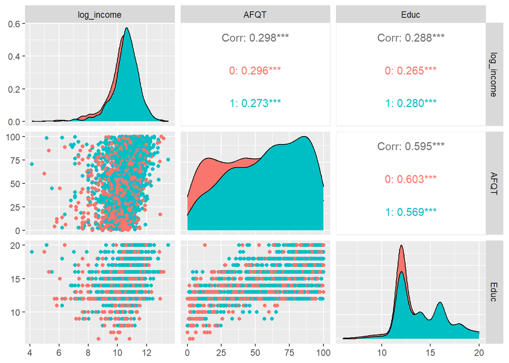

```r
#scatterplot matrix
ggpairs(esteem, columns = 3:5, ggplot2::aes(color = response_var))
```

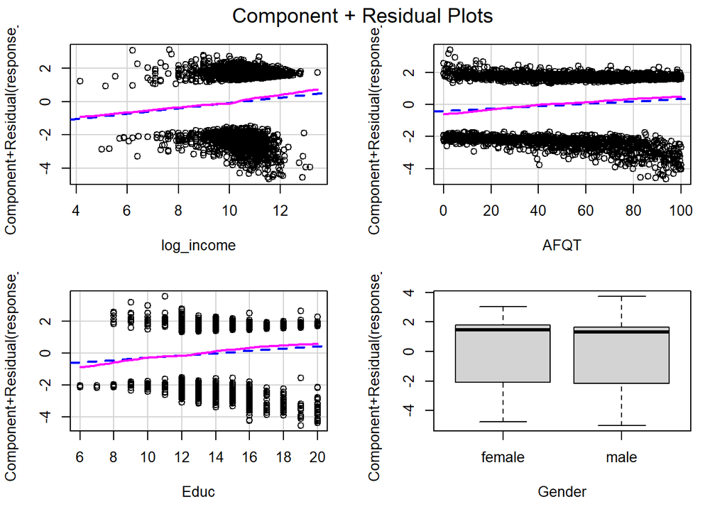

```r
#run the full model
esteem_glm <- glm(response_var ~ log_income + AFQT + Educ + Gender, family = binomial, data = esteem)
crPlots(esteem_glm)
```

```r
# REGRESSION ANALYSIS USING BACKWARD ELIMINATION
esteem_glm1 <- glm(response_var ~ log_income + AFQT + Educ + Gender, family = binomial, data = esteem)
summary(esteem_glm1)
```

```
##
## Call:
## glm(formula = response_var ~ log_income + AFQT + Educ + Gender,
##     family = binomial, data = esteem)
##
## Deviance Residuals:
##     Min       1Q   Median       3Q      Max
## -1.7891  -1.2240   0.8174   1.0410   1.6339
##
## Coefficients:
##              Estimate Std. Error z value Pr(>|z|)
## (Intercept) -2.773457   0.485833  -5.709 1.14e-08 ***
## log_income   0.165970   0.047114   3.523 0.000427 ***
## AFQT         0.007603   0.001842   4.128 3.65e-05 ***
## Educ         0.076135   0.021045   3.618 0.000297 ***
## Gendermale  -0.146214   0.087097  -1.679 0.093201 .
## ---
## Signif. codes:  0 '***' 0.001 '**' 0.01 '*' 0.05 '.' 0.1 ' ' 1
##
## (Dispersion parameter for binomial family taken to be 1)
##
##     Null deviance: 3508.3  on 2583  degrees of freedom
## Residual deviance: 3395.5  on 2579  degrees of freedom
## AIC: 3405.5
##
## Number of Fisher Scoring iterations: 4
```

```r
esteem_glm2 <- update(esteem_glm1, ~ . - Gender)
summary(esteem_glm2)
```

```
##
## Call:
## glm(formula = response_var ~ log_income + AFQT + Educ, family = binomial,
##     data = esteem)
##
## Deviance Residuals:
##     Min       1Q   Median       3Q      Max
## -1.8012  -1.2180   0.8194   1.0421   1.5546
##
## Coefficients:
##              Estimate Std. Error z value Pr(>|z|)
## (Intercept) -2.624464   0.476961  -5.502 3.75e-08 ***
## log_income   0.139145   0.044244   3.145 0.001661 **
## AFQT         0.007556   0.001840   4.106 4.02e-05 ***
## Educ         0.080432   0.020893   3.850 0.000118 ***
## ---
## Signif. codes:  0 '***' 0.001 '**' 0.01 '*' 0.05 '.' 0.1 ' ' 1
##
## (Dispersion parameter for binomial family taken to be 1)
##
##     Null deviance: 3508.3  on 2583  degrees of freedom
## Residual deviance: 3398.3  on 2580  degrees of freedom
## AIC: 3406.3
##
## Number of Fisher Scoring iterations: 4
```

```r
#run the optimal model
esteem_glm_optimal <- glm(response_var ~ log_income + AFQT + Educ, family = binomial, data = esteem)
summary(esteem_glm_optimal)
```

```
##
## Call:
## glm(formula = response_var ~ log_income + AFQT + Educ, family = binomial,
##     data = esteem)
##
## Deviance Residuals:
##     Min       1Q   Median       3Q      Max
## -1.8012  -1.2180   0.8194   1.0421   1.5546
##
## Coefficients:
##              Estimate Std. Error z value Pr(>|z|)
## (Intercept) -2.624464   0.476961  -5.502 3.75e-08 ***
## log_income   0.139145   0.044244   3.145 0.001661 **
## AFQT         0.007556   0.001840   4.106 4.02e-05 ***
## Educ         0.080432   0.020893   3.850 0.000118 ***
## ---
## Signif. codes:  0 '***' 0.001 '**' 0.01 '*' 0.05 '.' 0.1 ' ' 1
##
## (Dispersion parameter for binomial family taken to be 1)
##
##     Null deviance: 3508.3  on 2583  degrees of freedom
## Residual deviance: 3398.3  on 2580  degrees of freedom
## AIC: 3406.3
##
## Number of Fisher Scoring iterations: 4
```

```r
#back transform the estimates and CIs
exp(cbind(OR = coef(esteem_glm_optimal), confint(esteem_glm_optimal)))
```

```
##                     OR      2.5 %    97.5 %
## (Intercept) 0.07247859 0.02833288 0.1839753
## log_income  1.14929033 1.05387067 1.2536831
## AFQT        1.00758466 1.00396245 1.0112324
## Educ        1.08375511 1.04043127 1.1292663
```

**Supplemental 20.20_3rd** Excellent answer! Harrell (2015, 2021) argues that you shouldn’t automatically drop explanatory variables just because the p value is greater than 0.05. You dropped gender, but you could have presented it too. Females have 14% higher self esteem than males (1-exp(-.146214)), but the 95% CI includes 1. **Score 2.5/2.5**

## 21.21

```r
#read in the data
wildflower <- Sleuth3::ex1221

#take a look at the dataset
head(wildflower)
```

```
##   Year Region  Sep  Oct  Nov  Dec  Jan  Feb  Mar Total Rating Score
## 1 1970   baja 0.27 0.00 0.00 0.00 0.00 0.04 0.12  0.43   POOR     0
## 2 1971   baja 1.35 0.00 0.00 0.12 0.00 0.04 0.00  1.51   POOR     0
## 3 1972   baja 0.00 0.01 0.01 0.04 0.00 0.00 0.00  0.06   POOR     0
## 4 1974   baja 0.00 0.00 0.00 0.00 0.04 0.00 0.00  0.04   POOR     0
## 5 1975   baja 0.00 0.04 0.00 0.00 0.00 0.00 0.00  0.04   POOR     0
## 6 1976   baja 0.00 0.00 0.00 0.00 0.00 0.04 0.00  0.04   POOR     0
```

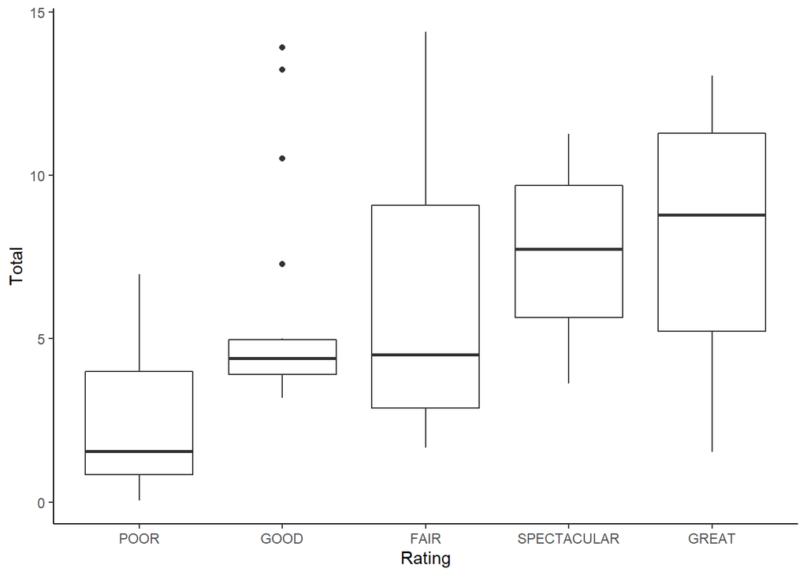

```r
#quick boxplot of the data
wildflower %>%
  ggplot() +
  geom_boxplot(aes(x = reorder(Rating, Total), y = Total)) +
  labs(x = "Rating") +
  theme_classic()
```

```r
#fit an ordinail logistic regression model
wildflower_polr <- polr(Rating ~ Total, data = wildflower)
summary(wildflower_polr)
```

```
##
## Re-fitting to get Hessian
```

```
## Call:
## polr(formula = Rating ~ Total, data = wildflower)
##
## Coefficients:
##         Value Std. Error t value
## Total -0.2254    0.05213  -4.323
##
## Intercepts:
##                  Value   Std. Error t value
## FAIR|GOOD        -2.8963  0.3872    -7.4792
## GOOD|GREAT       -1.8326  0.3242    -5.6519
## GREAT|POOR       -1.3942  0.3014    -4.6254
## POOR|SPECTACULAR  2.7378  0.5270     5.1954
##
## Residual Deviance: 275.863
## AIC: 285.863
```

```r
#back transform the estimate
exp(coef(wildflower_polr))
```

```
##     Total
## 0.7982163
```

```r
exp(confint(wildflower_polr))
```

```
##
## Re-fitting to get Hessian
```

```
##     2.5 %    97.5 %
## 0.7176115 0.8815277
```

For each unit increase in total rainfall in the months September to March, the wildflower display rating is only 79.82% as likely to increase rating status (95% CI: 71.76% to 88.15%)

**Supplemental 21.21_3rd** You are just one of two students to tackle the ordinal logistic. I forgot to present the method in class. Your estimates of the effects are wrong, but I don’t have time now to present the proper analysis. I’ll provide an R chunk that produces a nice graphic of the response, which improves dramatically with rainfall. **Score 2.5/2.5**

```r
library(car)
library(effects)  # for the Effect function, Fox & Weisberg (2019 p 274, 319)
library(Hmisc) # for describe function
library(MASS)
library(Sleuth3)
flower<-ex1221
str(flower)
```

```
## 'data.frame':    122 obs. of  12 variables:
##  $ Year  : int  1970 1971 1972 1974 1975 1976 1977 1978 1979 1980 ...
##  $ Region: Factor w/ 4 levels "baja","colorado",..: 1 1 1 1 1 1 1 1 1 1 ...
##  $ Sep   : num  0.27 1.35 0 0 0 0 0.55 0 0.04 0.02 ...
##  $ Oct   : num  0 0 0.01 0 0.04 0 0 2.55 0.4 0 ...
##  $ Nov   : num  0 0 0.01 0 0 0 0.4 0 1.02 0 ...
##  $ Dec   : num  0 0.12 0.04 0 0 0 0 0.49 0.95 0.04 ...
##  $ Jan   : num  0 0 0 0.04 0 0 0.26 0.27 0.86 0.12 ...
##  $ Feb   : num  0.04 0.04 0 0 0 0.04 0.26 0.87 0.2 0.4 ...
##  $ Mar   : num  0.12 0 0 0 0 0 0.37 0.05 0.08 0 ...
##  $ Total : num  0.43 1.51 0.06 0.04 0.04 0.04 1.84 4.23 3.55 0.58 ...
##  $ Rating: Factor w/ 5 levels "FAIR","GOOD",..: 4 4 4 4 4 4 4 2 2 4 ...
##  $ Score : int  0 0 0 0 0 0 0 2 2 0 ...
```

```r
describe(flower)
```

```
## flower
##
##  12  Variables      122  Observations
## --------------------------------------------------------------------------------
## Year
##        n  missing distinct     Info     Mean      Gmd      .05      .10
##      122        0       38    0.999     1981    11.72     1965     1967
##      .25      .50      .75      .90      .95
##     1973     1981     1989     1995     1997
##
## lowest : 1941 1964 1965 1966 1967, highest: 1996 1997 1998 1999 2000
## --------------------------------------------------------------------------------
## Region
##        n  missing distinct
##      122        0        4
##
## Value          baja colorado   mojave   upland
## Frequency        19       34       31       38
## Proportion    0.156    0.279    0.254    0.311
## --------------------------------------------------------------------------------
## Sep
##        n  missing distinct     Info     Mean      Gmd      .05      .10
##      122        0       66    0.974   0.6897   0.9614    0.000    0.000
##      .25      .50      .75      .90      .95
##    0.000    0.200    1.075    1.881    2.567
##
## lowest : 0.00 0.01 0.02 0.04 0.05, highest: 3.03 3.41 3.78 5.50 5.76
## --------------------------------------------------------------------------------
## Oct
##        n  missing distinct     Info     Mean      Gmd      .05      .10
##      122        0       58    0.946   0.5017   0.7771    0.000    0.000
##      .25      .50      .75      .90      .95
##    0.000    0.095    0.455    1.543    2.547
##
## lowest : 0.00 0.01 0.02 0.03 0.04, highest: 2.90 3.00 4.02 4.82 5.61
## --------------------------------------------------------------------------------
## Nov
##        n  missing distinct     Info     Mean      Gmd      .05      .10
##      122        0       63    0.965    0.402   0.5184   0.0000   0.0000
##      .25      .50      .75      .90      .95
```

[output cut: 50 more lines]

```
##
## Value             FAIR        GOOD       GREAT        POOR SPECTACULAR
## Frequency           18          20          10          70           4
## Proportion       0.148       0.164       0.082       0.574       0.033
## --------------------------------------------------------------------------------
## Score
##        n  missing distinct     Info     Mean      Gmd
##      122        0        5    0.803   0.8525    1.167
##
## lowest : 0 1 2 3 4, highest: 0 1 2 3 4
##
## Value          0     1     2     3     4
## Frequency     70    18    20    10     4
## Proportion 0.574 0.148 0.164 0.082 0.033
## --------------------------------------------------------------------------------
```

```r
mod.polr <- polr(factor(Score) ~ Total, data = flower)
summary(mod.polr)
```

```
##
## Re-fitting to get Hessian
```

```
## Call:
## polr(formula = factor(Score) ~ Total, data = flower)
##
## Coefficients:
##        Value Std. Error t value
## Total 0.3527    0.05799   6.082
##
## Intercepts:
##     Value  Std. Error t value
## 0|1 1.7655 0.3213     5.4950
## 1|2 2.6560 0.3716     7.1482
## 2|3 4.0673 0.4897     8.3064
## 3|4 5.6380 0.6884     8.1900
##
## Residual Deviance: 251.5781
## AIC: 261.5781
```

```r
# Test for the proportional odds model and assumptions Fox & Weisberg
# (2019, p 322)
poTest(mod.polr)
```

```
##
## Tests for Proportional Odds
## polr(formula = factor(Score) ~ Total, data = flower)
##
##         b[polr] b[>0] b[>1] b[>2] b[>3] Chisquare df Pr(>Chisq)
## Overall                                      9.87  3       0.02 *
## Total     0.353 0.625 0.308 0.311 0.223      9.87  3       0.02 *
## ---
## Signif. codes:  0 '***' 0.001 '**' 0.01 '*' 0.05 '.' 0.1 ' ' 1
```

```
##
## Re-fitting to get Hessian
```

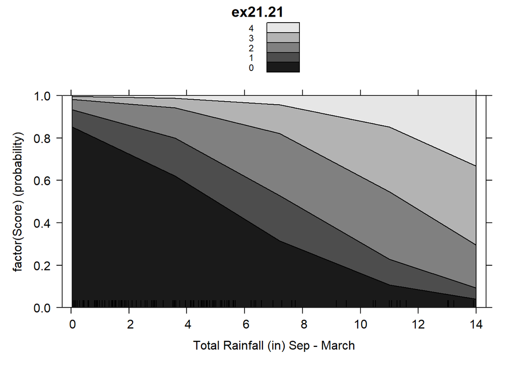

```r
# plot(Effect("Total"), mod.polr) # produces errors, don't know why

plot(Effect("Total", mod.polr),
     axes=list(y=list(style="stacked")),
     lines=list(col=gray(c(.1, .3, .5, .7, .9))),
     main = "ex21.21", xlab = "Total Rainfall (in) Sep - March")
```